# 重賞レース予測レポート【レース終了】

作成日時: 2026/06/28 16:29:10

☞ [マニュアル(pdf)](https://ryutoro-galois.github.io/keiba-predictor/manual/manual.pdf)

☞ 過去6年の同一レース結果: [2025年](https://ryutoro-galois.github.io/keiba-predictor/report/PredResult_2025y_raceDate_20250629_20250629.html), [2024年](https://ryutoro-galois.github.io/keiba-predictor/report/PredResult_2024y_raceDate_20240622_20240623.html), [2023年](https://ryutoro-galois.github.io/keiba-predictor/report/PredResult_2023y_raceDate_20230624_20230625.html), [2022年](https://ryutoro-galois.github.io/keiba-predictor/report/PredResult_2022y_raceDate_20220625_20220626.html), [2021年](https://ryutoro-galois.github.io/keiba-predictor/report/PredResult_2021y_raceDate_20210626_20210627.html), [2020年](https://ryutoro-galois.github.io/keiba-predictor/report/PredResult_2020y_raceDate_20200627_20200628.html)

☞ 過去4週間の別レース結果: [1週前(6/21)](https://ryutoro-galois.github.io/keiba-predictor/report/PredResult_2026y_raceDate_20260621_20260621.html), [2週前(6/13-14)](https://ryutoro-galois.github.io/keiba-predictor/report/PredResult_2026y_raceDate_20260613_20260614.html), [3週前(6/7)](https://ryutoro-galois.github.io/keiba-predictor/report/PredResult_2026y_raceDate_20260607_20260607.html), [4週前(5/30-31)](https://ryutoro-galois.github.io/keiba-predictor/report/PredResult_2026y_raceDate_20260530_20260531.html)

☞ netkeiba: [ラジオNIKKEI賞(GⅢ)](https://race.netkeiba.com/race/result.html?race_id=202603020211&rf=race_submenu), [函館記念(GⅢ)](https://race.netkeiba.com/race/result.html?race_id=202602010611&rf=race_submenu)

☞ レース結果(csv): [6/20-21](https://ryutoro-galois.github.io/keiba-predictor/csv/race_result_20260620_20260621.csv)

## 【レース結果(1)】人気と着順の関係

### 【ラジオNIKKEI賞(2026/06/28(日))】

【ラジオNIKKEI賞(GⅢ)】  
2026/06/28(日), 03_福島, 芝右1800m

[interactive chart not shown]

### 【函館記念(2026/06/28(日))】

【函館記念(GⅢ)】  
2026/06/28(日), 02_函館, 芝右2000m

[interactive chart not shown]

## 【レース結果(2)】コーナー通過順位

### 【ラジオNIKKEI賞(2026/06/28(日))】

【ラジオNIKKEI賞(GⅢ)】  
2026/06/28(日), 03_福島, 芝右1800m

[interactive chart not shown]

### 【函館記念(2026/06/28(日))】

【函館記念(GⅢ)】  
2026/06/28(日), 02_函館, 芝右2000m

[interactive chart not shown]

## 0. 推し馬予測 (AI予測)

### 【ラジオNIKKEI賞(GⅢ) 2026/06/28(日)】

- 本命(◎): 1-3着内確率(勝負強さ)が1位の馬
- 対抗(◯): 1-3着内確率が2-N位(20%程度以上)の中で予測タイムが最も速い馬
- 3番手(▲): 1-3着内確率が2-N位(20%程度以上)のでダークホース確率が最も高い馬
- 穴: ダークホース確率が上位1-M位(40%程度以上)の中で1-3着内確率が最も高い馬

| 推し馬 | 枠番 | 馬番 | 人気 | オッズ | 馬名 | 騎手 | 調教師 | 予測タイム(sec) | 1_順位 | 1-3着内確率(%) | 2_順位 | ﾀﾞｰｸﾎｰｽ確率(%) | 3_順位 |
| --- | --- | --- | --- | --- | --- | --- | --- | --- | --- | --- | --- | --- | --- |
| 本命(◎) | 3 | 6 | 3 | 6.9 | コルテオソレイユ | 荻野極 | 佐藤悠太 | 109.4 | 8 | 44.2 | 1 | 0.4 | 14 |
| 対抗(◯) | 1 | 1 | 5 | 9.4 | ルージュボヤージュ | 北村宏司 | 木村哲也 | 107.8 | 2 | 23.8 | 4 | 1.0 | 11 |
| 3番手(▲) | 2 | 3 | 7 | 12.2 | ジーネキング | 菊沢一樹 | 斎藤誠 | 109.5 | 10 | 22.8 | 5 | 1.3 | 10 |
| 穴 | 5 | 10 | 16 | 96.2 | ガリレア | 石橋脩 | 清水英克 | 109.3 | 6 | 18.0 | 6 | 37.8 | 2 |

### 【函館記念(GⅢ) 2026/06/28(日)】

- 本命(◎): 1-3着内確率(勝負強さ)が1位の馬
- 対抗(◯): 1-3着内確率が2-N位(20%程度以上)の中で予測タイムが最も速い馬
- 3番手(▲): 1-3着内確率が2-N位(20%程度以上)のでダークホース確率が最も高い馬
- 穴: ダークホース確率が上位1-M位(40%程度以上)の中で1-3着内確率が最も高い馬

| 推し馬 | 枠番 | 馬番 | 人気 | オッズ | 馬名 | 騎手 | 調教師 | 予測タイム(sec) | 1_順位 | 1-3着内確率(%) | 2_順位 | ﾀﾞｰｸﾎｰｽ確率(%) | 3_順位 |
| --- | --- | --- | --- | --- | --- | --- | --- | --- | --- | --- | --- | --- | --- |
| 本命(◎) | 8 | 14 | 1 | 6.1 | フィーリウス | 丹内祐次 | 手塚貴久 | 118.5 | 2 | 28.6 | 1 | 0.6 | 14 |
| 対抗(◯) | 5 | 8 | 4 | 8.1 | ケイアイセナ | 武豊 | 平田修 | 126.3 | 5 | 22.7 | 3 | 1.6 | 9 |
| 穴 | 2 | 3 | 10 | 20.6 | ピースワンデュック | 佐々木大輔 | 大竹正博 | 122.2 | 4 | 9.8 | 8 | 67.5 | 1 |

## 1. 予測チャート (タイム/勝負強さ)

### 【ラジオNIKKEI賞(GⅢ)】

2026/06/28(日), 03_福島, 芝右1800m

[interactive chart not shown]

### 【函館記念(GⅢ)】

2026/06/28(日), 02_函館, 芝右2000m

[interactive chart not shown]

## 2. オッズモニタリング (毎時)

### 【ラジオNIKKEI賞】

[interactive chart not shown]

### 【函館記念】

[interactive chart not shown]

## 3. 出馬表

### 【ラジオNIKKEI賞 2026/06/28(日) 】

[figure not shown]

### 【函館記念 2026/06/28(日) 】

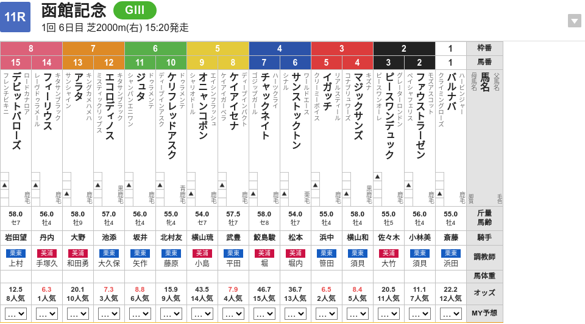

## 4. 単勝予測結果

### 【ラジオNIKKEI賞(GⅢ) 2026/06/28(日)】

| 枠番 | 馬番 | 人気 | オッズ | 馬名 | 騎手 | 調教師 | 予測タイム(sec) | 1_順位 | 1-3着内確率(%) | 2_順位 | ﾀﾞｰｸﾎｰｽ確率(%) | 3_順位 |
| --- | --- | --- | --- | --- | --- | --- | --- | --- | --- | --- | --- | --- |
| 1 | 1 | 5 | 9.4 | ルージュボヤージュ | 北村宏司 | 木村哲也 | 107.8 | 2 | 23.8 | 4 | 1.0 | 11.0 |
| 1 | 2 | 8 | 14.1 | クカイリモク | Ｆ．ゴンサルベス | 堀宣行 | 112.3 | 11 | 16.4 | 8 | 1.3 | 9.0 |
| 2 | 3 | 7 | 12.2 | ジーネキング | 菊沢一樹 | 斎藤誠 | 109.5 | 10 | 22.8 | 5 | 1.3 | 10.0 |
| 2 | 4 | 15 | 68.8 | サイモンシャリオ | 田口貫太 | 梅田智之 | 116.9 | 14 | 3.3 | 15 | 11.7 | 7.0 |
| 3 | 5 | 1 | 5.8 | リッツパーティー | 横山武史 | 岩戸孝樹 | 105.9 | 1 | 17.1 | 7 | 0.5 | 13.0 |
| 3 | 6 | 3 | 6.9 | コルテオソレイユ | 荻野極 | 佐藤悠太 | 109.4 | 8 | 44.2 | 1 | 0.4 | 14.0 |
| 4 | 7 | 14 | 55.7 | ショウナンガルフ | 丸山元気 | 須貝尚介 | 108.9 | 3 | 9.3 | 13 | 38.6 | 1.0 |
| 4 | 8 | 9 | 15.0 | ディールメーカー | 高杉吏麒 | 大和田成 | 112.6 | 12 | 12.4 | 10 | 32.9 | 3.0 |
| 5 | 9 | 11 | 18.5 | キンググローリー | 石川裕紀人 | 古賀慎明 | 117.1 | 15 | 3.7 | 14 | 9.0 | 8.0 |
| 5 | 10 | 16 | 96.2 | ガリレア | 石橋脩 | 清水英克 | 109.3 | 6 | 18.0 | 6 | 37.8 | 2.0 |

[output cut: 6 more lines]

### 【函館記念(GⅢ) 2026/06/28(日)】

| 枠番 | 馬番 | 人気 | オッズ | 馬名 | 騎手 | 調教師 | 予測タイム(sec) | 1_順位 | 1-3着内確率(%) | 2_順位 | ﾀﾞｰｸﾎｰｽ確率(%) | 3_順位 |
| --- | --- | --- | --- | --- | --- | --- | --- | --- | --- | --- | --- | --- |
| 1 | 1 | 12 | 21.3 | バルナバ | 斎藤新 | 浜田多実雄 | 134.7 | 15 | 2.1 | 15 | 13.3 | 7 |
| 2 | 2 | 7 | 10.8 | ファウストラーゼン | 小林美駒 | 須貝尚介 | 127.7 | 7 | 13.3 | 7 | 1.4 | 11 |
| 2 | 3 | 10 | 20.6 | ピースワンデュック | 佐々木大輔 | 大竹正博 | 122.2 | 4 | 9.8 | 8 | 67.5 | 1 |
| 3 | 4 | 5 | 8.4 | マジックサンズ | 横山和生 | 須貝尚介 | 127.5 | 6 | 17.3 | 6 | 1.8 | 8 |
| 3 | 5 | 2 | 6.8 | イガッチ | 浜中俊 | 笹田和秀 | 129.7 | 12 | 17.7 | 5 | 0.6 | 13 |
| 4 | 6 | 13 | 35.4 | サンストックトン | 松本大輝 | 堀内岳志 | 129.4 | 11 | 4.1 | 11 | 25.1 | 4 |
| 4 | 7 | 15 | 46.3 | チャックネイト | 鮫島克駿 | 堀宣行 | 129.7 | 13 | 3.8 | 12 | 58.9 | 2 |
| 5 | 8 | 4 | 8.1 | ケイアイセナ | 武豊 | 平田修 | 126.3 | 5 | 22.7 | 3 | 1.6 | 9 |
| 5 | 9 | 14 | 42.8 | オニャンコポン | 横山琉人 | 小島茂之 | 118.5 | 2 | 6.3 | 10 | 18.0 | 6 |
| 6 | 10 | 9 | 15.8 | ケリフレッドアスク | 北村友一 | 藤原英昭 | 128.0 | 8 | 8.0 | 9 | 48.1 | 3 |

[output cut: 5 more lines]

## 5. 人気と着順の乖離率推移

### 【ラジオNIKKEI賞_2006y_2019y】

[interactive chart not shown]

### 【函館記念_1990y_2019y】

[interactive chart not shown]

### 【ラジオNIKKEI賞_2006y_2019y】

| No | 開催年 | 不整合率(%) | 頭数 | 人気別着順(1-3位) | 人気別着順(全体) |
| --- | --- | --- | --- | --- | --- |
| 14 | 2019 | 59.5 | 16頭 | 3-9-6 | 3\|9\|6\|7\|13\|5\|4\|15\|1\|14\|2\|11\|8\|16\|10\|12 |
| 13 | 2018 | 40.8 | 13頭 | 2-1-9 | 2\|1\|9\|11\|6\|7\|8\|13\|5\|4\|3\|10\|12 |
| 12 | 2017 | 46.1 | 12頭 | 2-8-9 | 2\|8\|9\|3\|6\|1\|10\|7\|12\|11\|5\|4 |
| 11 | 2016 | 28.2 | 16頭 | 1-9-5 | 1\|9\|5\|3\|2\|6\|8\|10\|4\|7\|11\|16\|12\|15\|13\|14 |
| 10 | 2015 | 42.2 | 16頭 | 1-4-12 | 1\|4\|12\|3\|10\|11\|9\|14\|6\|7\|15\|8\|13\|16\|5\|2 |
| 9 | 2014 | 33.8 | 16頭 | 5-1-7 | 5\|1\|7\|10\|16\|13\|6\|2\|11\|9\|4\|3\|8\|12\|15\|14 |
| 8 | 2013 | 69.9 | 16頭 | 8-14-5 | 8\|14\|5\|3\|6\|15\|7\|10\|13\|2\|4\|12\|16\|9\|1\|11 |
| 7 | 2012 | 31.4 | 16頭 | 2-1-16 | 2\|1\|16\|5\|9\|10\|11\|7\|15\|6\|3\|4\|8\|13\|12\|14 |
| 6 | 2011 | 37.6 | 11頭 | 2-3-1 | 2\|3\|1\|8\|6\|9\|11\|7\|4\|10\|12 |
| 5 | 2010 | 46.8 | 16頭 | 3-2-6 | 3\|2\|6\|7\|1\|4\|10\|13\|9\|14\|15\|8\|5\|12\|16\|11 |

[output cut: 4 more lines]

### 【函館記念_1990y_2019y】

| No | 開催年 | 不整合率(%) | 頭数 | 人気別着順(1-3位) | 人気別着順(全体) |
| --- | --- | --- | --- | --- | --- |
| 30 | 2019 | 31.6 | 16頭 | 1-9-3 | 1\|9\|3\|7\|12\|2\|8\|6\|15\|5\|10\|14\|4\|13\|16\|11 |
| 29 | 2018 | 46.4 | 15頭 | 5-7-13 | 5\|7\|13\|2\|3\|1\|15\|6\|12\|4\|11\|14\|9\|8\|10 |
| 28 | 2017 | 58.2 | 16頭 | 5-14-7 | 5\|14\|7\|3\|11\|1\|12\|9\|8\|6\|4\|16\|15\|10\|2\|13 |
| 27 | 2016 | 40.8 | 16頭 | 3-13-9 | 3\|13\|9\|16\|1\|4\|14\|11\|2\|6\|12\|10\|5\|15\|8\|7 |
| 26 | 2015 | 42.8 | 16頭 | 3-10-7 | 3\|10\|7\|1\|5\|15\|8\|2\|12\|6\|4\|9\|16\|11\|13\|14 |
| 25 | 2014 | 45.7 | 16頭 | 2-8-7 | 2\|8\|7\|9\|12\|15\|11\|16\|5\|1\|13\|4\|6\|14\|10\|3 |
| 24 | 2013 | 55.3 | 16頭 | 3-7-8 | 3\|7\|8\|2\|4\|5\|6\|10\|14\|1\|15\|12\|11\|16\|13\|9 |
| 23 | 2012 | 44.5 | 16頭 | 4-8-7 | 4\|8\|7\|1\|10\|3\|15\|6\|2\|13\|5\|12\|9\|16\|14\|11 |
| 22 | 2011 | 61.1 | 16頭 | 4-12-7 | 4\|12\|7\|6\|3\|8\|11\|1\|16\|5\|9\|13\|10\|15\|14\|2 |
| 21 | 2010 | 25.5 | 16頭 | 2-1-5 | 2\|1\|5\|11\|3\|6\|8\|10\|9\|4\|15\|14\|16\|7\|13\|12 |

[output cut: 20 more lines]

## 6. 1-3番人気馬の着順分類予測

### 【ラジオNIKKEI賞】

| 分類 | 凡例 | 発生確率(%) | 当該レース | 当該レースランク | 直近1年間 |
| --- | --- | --- | --- | --- | --- |
| 1: 1番人気のみ (1_pop1) | 1 \| * \| * | 17.6 | 1.17 | 1.64 | 0.00 |
| 4: 1,2番人気のみ (4_pop12) | 1 \| 2 \| * | 17.6 | 1.76 | 1.64 | 0.00 |
| 8: 1,2,3番人気すべて着外 (8_darkhorse) | * \| * \| * | 13.8 | 1.38 | 0.59 | 0.00 |
| 5: 1,3番人気のみ (5_pop13) | 1 \| 3 \| * | 13.0 | 0.00 | 1.04 | 0.26 |
| 3: 3番人気のみ (3_pop3) | 3 \| * \| * | 12.2 | 0.35 | 0.62 | 0.24 |
| 6: 2,3番人気のみ (6_pop23) | 2 \| 3 \| * | 9.8 | 1.96 | 5.44 | 0.00 |
| 2: 2番人気のみ (2_pop2) | 2 \| * \| * | 9.1 | 0.45 | 0.57 | 0.00 |
| 7: 1,2,3番人気すべて着内 (7_pop123) | 1 \| 2 \| 3 | 6.9 | 1.38 | 1.28 | 0.00 |

### 【函館記念】

| 分類 | 凡例 | 発生確率(%) | 当該レース | 当該レースランク | 直近1年間 |
| --- | --- | --- | --- | --- | --- |
| 1: 1番人気のみ (1_pop1) | 1 \| * \| * | 17.6 | 2.12 | 1.64 | 0.00 |
| 4: 1,2番人気のみ (4_pop12) | 1 \| 2 \| * | 17.5 | 1.58 | 1.64 | 0.00 |
| 5: 1,3番人気のみ (5_pop13) | 1 \| 3 \| * | 16.2 | 0.84 | 1.30 | 0.32 |
| 8: 1,2,3番人気すべて着外 (8_darkhorse) | * \| * \| * | 13.7 | 0.45 | 0.59 | 0.00 |
| 6: 2,3番人気のみ (6_pop23) | 2 \| 3 \| * | 9.7 | 0.00 | 5.39 | 0.00 |
| 3: 3番人気のみ (3_pop3) | 3 \| * \| * | 9.2 | 0.83 | 0.47 | 0.18 |
| 2: 2番人気のみ (2_pop2) | 2 \| * \| * | 9.1 | 0.65 | 0.57 | 0.00 |
| 7: 1,2,3番人気すべて着内 (7_pop123) | 1 \| 2 \| 3 | 6.9 | 1.23 | 1.28 | 0.00 |

## 7. 3連複予測結果

### 【ラジオNIKKEI賞(GⅢ) 2026/06/28(日)】

| 分類 | 馬番 | 枠番 | 人気 | 平均予測タイム(sec) | 1-3着内確率(%) | ﾀﾞｰｸﾎｰｽ確率(%) | 馬名 | 騎手 | 調教師 |
| --- | --- | --- | --- | --- | --- | --- | --- | --- | --- |
| 6: 2,3番人気のみ (6_pop23) | 12-6-13 | 6-3-7 | 2-3-4 | 109.27 | 6.91 | 0.00 | ローベルクランツ \| コルテオソレイユ \| サノノグレーター | 松山弘平 \| 荻野極 \| 田辺裕信 | 小林真也 \| 佐藤悠太 \| 尾形和幸 |
| 6: 2,3番人気のみ (6_pop23) | 12-6-1 | 6-3-1 | 2-3-5 | 108.87 | 4.45 | 0.00 | ローベルクランツ \| コルテオソレイユ \| ルージュボヤージュ | 松山弘平 \| 荻野極 \| 北村宏司 | 小林真也 \| 佐藤悠太 \| 木村哲也 |
| 6: 2,3番人気のみ (6_pop23) | 12-6-3 | 6-3-2 | 2-3-7 | 109.43 | 4.27 | 0.00 | ローベルクランツ \| コルテオソレイユ \| ジーネキング | 松山弘平 \| 荻野極 \| 菊沢一樹 | 小林真也 \| 佐藤悠太 \| 斎藤誠 |
| 3: 3番人気のみ (3_pop3) | 6-13-1 | 3-7-1 | 3-4-5 | 108.73 | 3.87 | 0.00 | コルテオソレイユ \| サノノグレーター \| ルージュボヤージュ | 荻野極 \| 田辺裕信 \| 北村宏司 | 佐藤悠太 \| 尾形和幸 \| 木村哲也 |
| 2: 2番人気のみ (2_pop2) | 12-13-1 | 6-7-1 | 2-4-5 | 108.73 | 3.72 | 0.00 | ローベルクランツ \| サノノグレーター \| ルージュボヤージュ | 松山弘平 \| 田辺裕信 \| 北村宏司 | 小林真也 \| 尾形和幸 \| 木村哲也 |
| 3: 3番人気のみ (3_pop3) | 6-13-3 | 3-7-2 | 3-4-7 | 109.30 | 3.71 | 0.00 | コルテオソレイユ \| サノノグレーター \| ジーネキング | 荻野極 \| 田辺裕信 \| 菊沢一樹 | 佐藤悠太 \| 尾形和幸 \| 斎藤誠 |
| 2: 2番人気のみ (2_pop2) | 12-13-3 | 6-7-2 | 2-4-7 | 109.30 | 3.57 | 0.00 | ローベルクランツ \| サノノグレーター \| ジーネキング | 松山弘平 \| 田辺裕信 \| 菊沢一樹 | 小林真也 \| 尾形和幸 \| 斎藤誠 |
| 6: 2,3番人気のみ (6_pop23) | 12-6-10 | 6-3-5 | 2-3-16 | 109.37 | 3.37 | 0.00 | ローベルクランツ \| コルテオソレイユ \| ガリレア | 松山弘平 \| 荻野極 \| 石橋脩 | 小林真也 \| 佐藤悠太 \| 清水英克 |
| 7: 1,2,3番人気すべて着内 (7_pop123) | 5-12-6 | 3-6-3 | 1-2-3 | 108.23 | 3.20 | 0.00 | リッツパーティー \| ローベルクランツ \| コルテオソレイユ | 横山武史 \| 松山弘平 \| 荻野極 | 岩戸孝樹 \| 小林真也 \| 佐藤悠太 |
| 6: 2,3番人気のみ (6_pop23) | 12-6-2 | 6-3-1 | 2-3-8 | 110.37 | 3.08 | 0.00 | ローベルクランツ \| コルテオソレイユ \| クカイリモク | 松山弘平 \| 荻野極 \| Ｆ．ゴンサルベス | 小林真也 \| 佐藤悠太 \| 堀宣行 |

[output cut: 550 more lines]

### 【函館記念(GⅢ) 2026/06/28(日)】

| 分類 | 馬番 | 枠番 | 人気 | 平均予測タイム(sec) | 1-3着内確率(%) | ﾀﾞｰｸﾎｰｽ確率(%) | 馬名 | 騎手 | 調教師 |
| --- | --- | --- | --- | --- | --- | --- | --- | --- | --- |
| 5: 1,3番人気のみ (5_pop13) | 14-12-8 | 8-7-5 | 1-3-4 | 124.37 | 1.71 | 0.00 | フィーリウス \| エコロディノス \| ケイアイセナ | 丹内祐次 \| 池添謙一 \| 武豊 | 手塚貴久 \| 大久保龍志 \| 平田修 |
| 5: 1,3番人気のみ (5_pop13) | 14-12-11 | 8-7-6 | 1-3-6 | 124.93 | 1.66 | 0.00 | フィーリウス \| エコロディノス \| ジュタ | 丹内祐次 \| 池添謙一 \| 坂井瑠星 | 手塚貴久 \| 大久保龍志 \| 矢作芳人 |
| 1: 1番人気のみ (1_pop1) | 14-8-11 | 8-5-6 | 1-4-6 | 124.27 | 1.44 | 0.00 | フィーリウス \| ケイアイセナ \| ジュタ | 丹内祐次 \| 武豊 \| 坂井瑠星 | 手塚貴久 \| 平田修 \| 矢作芳人 |
| 7: 1,2,3番人気すべて着内 (7_pop123) | 14-5-12 | 8-3-7 | 1-2-3 | 125.50 | 1.33 | 0.00 | フィーリウス \| イガッチ \| エコロディノス | 丹内祐次 \| 浜中俊 \| 池添謙一 | 手塚貴久 \| 笹田和秀 \| 大久保龍志 |
| 3: 3番人気のみ (3_pop3) | 12-8-11 | 7-5-6 | 3-4-6 | 127.53 | 1.32 | 0.00 | エコロディノス \| ケイアイセナ \| ジュタ | 池添謙一 \| 武豊 \| 坂井瑠星 | 大久保龍志 \| 平田修 \| 矢作芳人 |
| 5: 1,3番人気のみ (5_pop13) | 14-12-4 | 8-7-3 | 1-3-5 | 124.77 | 1.30 | 0.00 | フィーリウス \| エコロディノス \| マジックサンズ | 丹内祐次 \| 池添謙一 \| 横山和生 | 手塚貴久 \| 大久保龍志 \| 須貝尚介 |
| 4: 1,2番人気のみ (4_pop12) | 14-5-8 | 8-3-5 | 1-2-4 | 124.83 | 1.15 | 0.00 | フィーリウス \| イガッチ \| ケイアイセナ | 丹内祐次 \| 浜中俊 \| 武豊 | 手塚貴久 \| 笹田和秀 \| 平田修 |
| 1: 1番人気のみ (1_pop1) | 14-8-4 | 8-5-3 | 1-4-5 | 124.10 | 1.13 | 0.00 | フィーリウス \| ケイアイセナ \| マジックサンズ | 丹内祐次 \| 武豊 \| 横山和生 | 手塚貴久 \| 平田修 \| 須貝尚介 |
| 4: 1,2番人気のみ (4_pop12) | 14-5-11 | 8-3-6 | 1-2-6 | 125.40 | 1.12 | 0.00 | フィーリウス \| イガッチ \| ジュタ | 丹内祐次 \| 浜中俊 \| 坂井瑠星 | 手塚貴久 \| 笹田和秀 \| 矢作芳人 |
| 1: 1番人気のみ (1_pop1) | 14-4-11 | 8-3-6 | 1-5-6 | 124.67 | 1.10 | 0.00 | フィーリウス \| マジックサンズ \| ジュタ | 丹内祐次 \| 横山和生 \| 坂井瑠星 | 手塚貴久 \| 須貝尚介 \| 矢作芳人 |

[output cut: 445 more lines]

## 8. 直近の全レース情報

| No | 日付 | 競馬場 | R | 発走 | レース名 | 距離 | 頭数 | URL(netkeiba) |
| --- | --- | --- | --- | --- | --- | --- | --- | --- |
| 1 | 2026/06/27(土) | 03_福島 | 9R | 14:35 | さくらんぼ特 | 1150 | 23頭 | https://race.netkeiba.com/race/shutuba.html?race_id=202603020109&amp;rf=race_list |
| 2 | 2026/06/27(土) | 03_福島 | 10R | 15:10 | いわき特別 | 1700 | 19頭 | https://race.netkeiba.com/race/shutuba.html?race_id=202603020110&amp;rf=race_list |
| 3 | 2026/06/27(土) | 03_福島 | 11R | 15:45 | バーデンBC | 2000 | 9頭 | https://race.netkeiba.com/race/shutuba.html?race_id=202603020111&amp;rf=race_list |
| 4 | 2026/06/27(土) | 10_小倉 | 9R | 14:20 | 八代特別 | 2000 | 12頭 | https://race.netkeiba.com/race/shutuba.html?race_id=202610020109&amp;rf=race_list |
| 5 | 2026/06/27(土) | 10_小倉 | 10R | 14:55 | 宗像特別 | 1200 | 15頭 | https://race.netkeiba.com/race/shutuba.html?race_id=202610020110&amp;rf=race_list |
| 6 | 2026/06/27(土) | 10_小倉 | 11R | 15:30 | 薩摩S | 1700 | 19頭 | https://race.netkeiba.com/race/shutuba.html?race_id=202610020111&amp;rf=race_list |
| 7 | 2026/06/27(土) | 02_函館 | 9R | 14:10 | 長万部特別 | 1200 | 21頭 | https://race.netkeiba.com/race/shutuba.html?race_id=202602010509&amp;rf=race_list |
| 8 | 2026/06/27(土) | 02_函館 | 10R | 14:45 | 洞爺湖特別 | 2000 | 12頭 | https://race.netkeiba.com/race/shutuba.html?race_id=202602010510&amp;rf=race_list |
| 9 | 2026/06/27(土) | 02_函館 | 11R | 15:20 | 青函S | 1200 | 15頭 | https://race.netkeiba.com/race/shutuba.html?race_id=202602010511&amp;rf=race_list |
| 10 | 2026/06/28(日) | 03_福島 | 9R | 14:35 | 松島特別 | 2000 | 15頭 | https://race.netkeiba.com/race/shutuba.html?race_id=202603020209&amp;rf=race_list |

[output cut: 9 more lines]